# Lab Exercise (Essentials of Data Analytics)

### 17MIS1022

### Date : 08-Feb-2021

```r
library(tidyverse)
library(ggpubr)
library(MASS)
library(caTools)
library(dplyr)
library(caret)
str(cars)
```

```
## 'data.frame':    50 obs. of  2 variables:
##  $ speed: num  4 4 7 7 8 9 10 10 10 11 ...
##  $ dist : num  2 10 4 22 16 10 18 26 34 17 ...
```

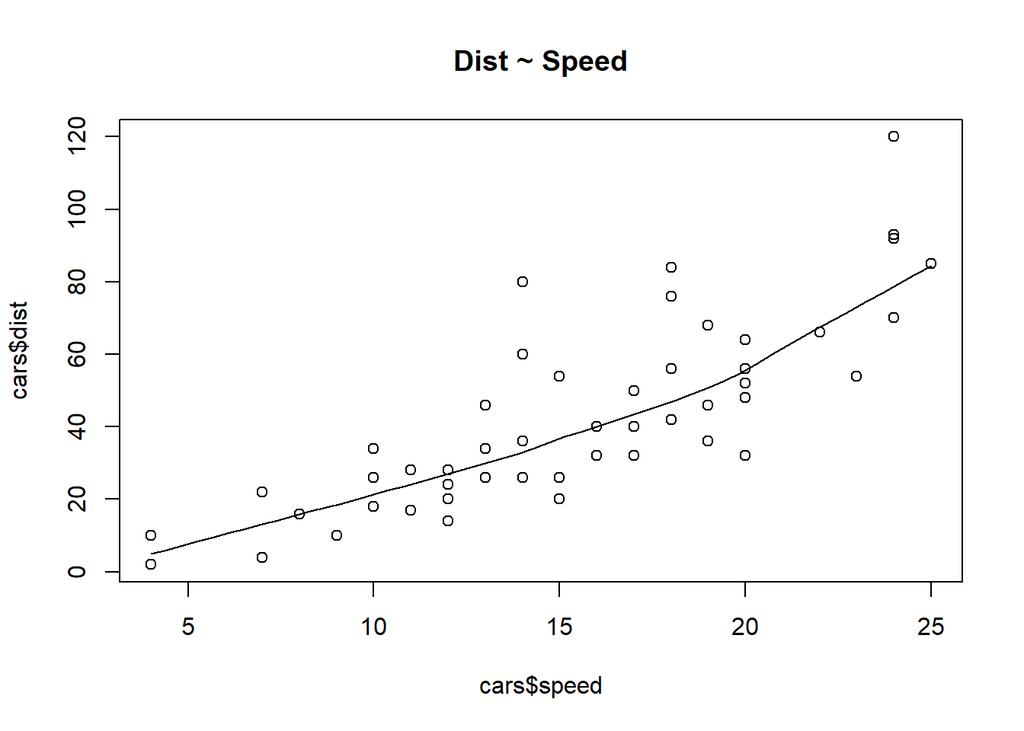

```r
scatter.smooth(x=cars$speed, y=cars$dist, main="Dist ~ Speed")
```

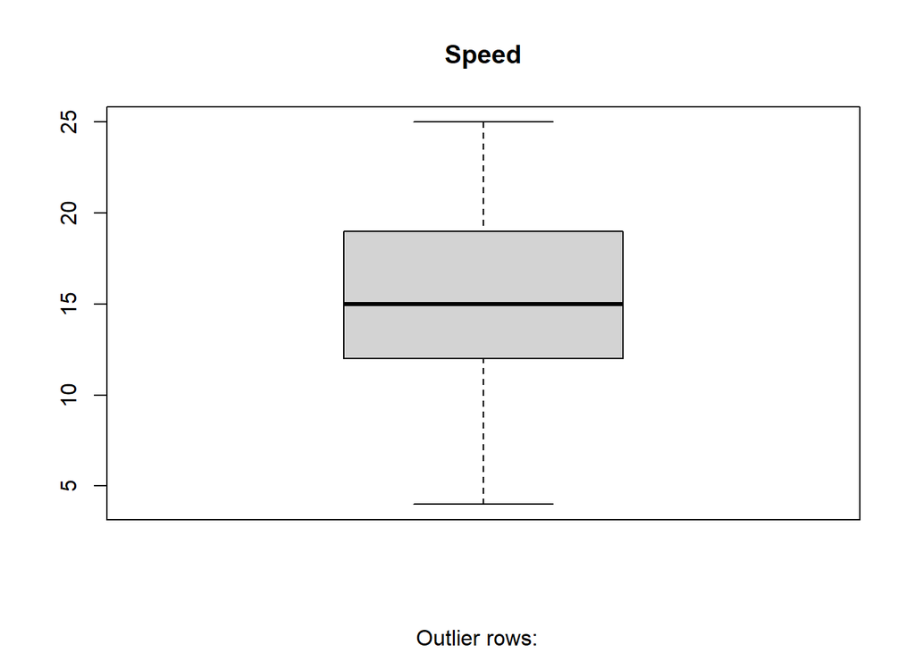

```r
boxplot(cars$speed, main="Speed", sub=paste("Outlier rows: ", boxplot.stats(cars$speed)$out))  # box plot for 'speed'
```

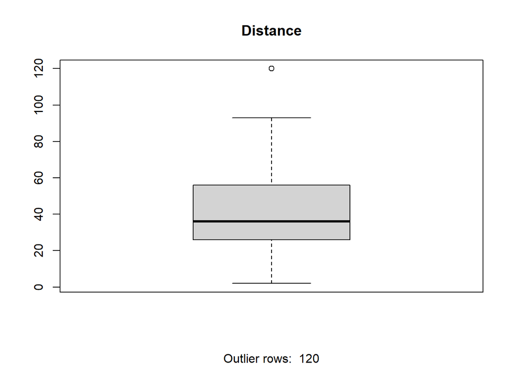

```r
boxplot(cars$dist, main="Distance", sub=paste("Outlier rows: ", boxplot.stats(cars$dist)$out))  # box plot for 'distance'
```

```r
training.samples <- cars$dist %>%createDataPartition(p = 0.7, list = FALSE)
train <- cars[training.samples, ]
test <- cars[-training.samples, ]
nrow(test)
```

```
## [1] 13
```

- y = m*x + c is the equation of best fitting line where m is slope and c is y-intercept.This equation can be used to predict the distance of car travel.
- m can be calculated using the formula Covariance(x,y) / Variance(x)
- c can be calculated by substituting the mean values of (x,y) in the equation and m value.
- Calculating Covariance

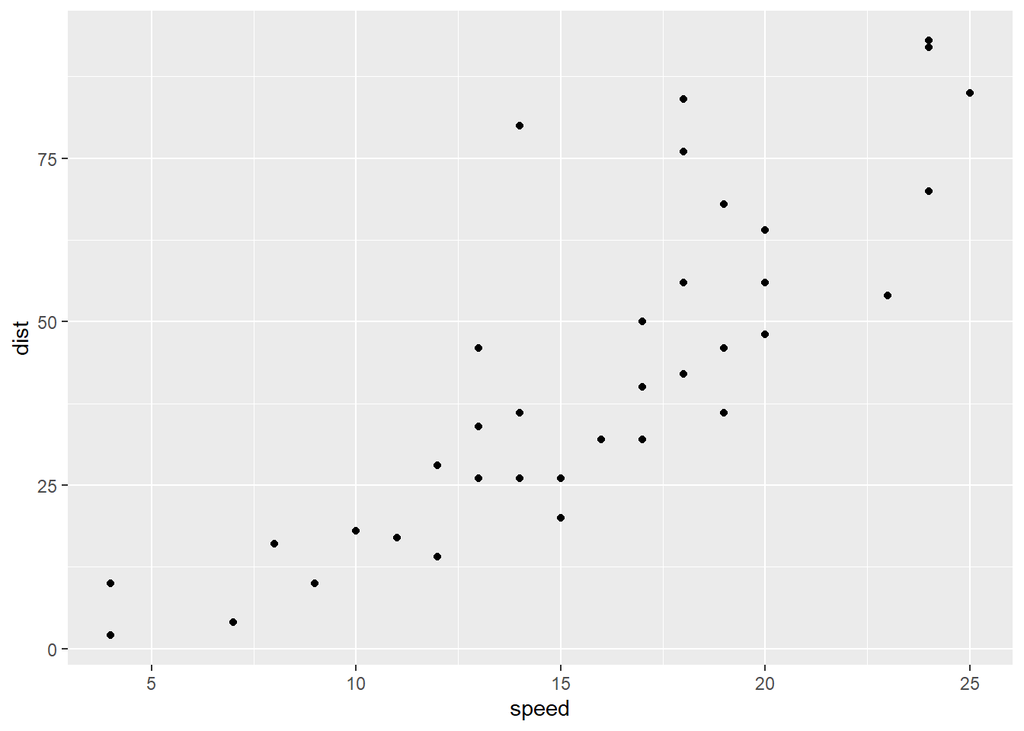

```r
# y = mx+c
mean_x =sum(train$speed) / nrow(train)
mean_y=sum(train$dist) / nrow(train)


library(ggplot2)
ggplot(train)+geom_point(mapping = aes(x=speed,y=dist))
```

```r
cov_xy =0

for(i in seq(length(train$speed))){

  mean_diffx = train$speed[i] - mean_x
  mean_diffy = train$dist[i] - mean_y
  cov_xy= cov_xy+mean_diffx*mean_diffy

}

cov_xy
```

```
## [1] 4090.892
```

- Variance

```r
variance<-function(x){
  var_xy = 0
  for(i in seq(length(x)))
    {

    s = x[i] - mean_x
    var_xy= var_xy+s*s


  }
  print(var_xy)



}



variance(train$speed)
```

```
## [1] 1034.919
```

m (slope) and c (y-intercept) are calculated.

```r
m = cov_xy / variance(train$speed)
```

```
## [1] 1034.919
```

```r
m
```

```
## [1] 3.952862
```

```r
c = mean_y - m*(mean_x)
c
```

```
## [1] -19.18382
```

- Predicting the distance by using the line equation

```r
predictor<-function(x){
  val = m*x+c
  print(val)
}

predictor(10)
```

```
## [1] 20.3448
```

- Verifying calculated values with the regression libraries available in r(lm).

```r
library(caret)
colnames(train)
```

```
## [1] "speed" "dist"
```

```r
model<- lm(dist~speed,data=train)
summary(model)
```

```
##
## Call:
## lm(formula = dist ~ speed, data = train)
##
## Residuals:
##     Min      1Q  Median      3Q     Max
## -20.109  -9.968  -2.345   5.362  43.844
##
## Coefficients:
##             Estimate Std. Error t value Pr(>|t|)
## (Intercept) -19.1838     7.4190  -2.586    0.014 *
## speed         3.9529     0.4505   8.774 2.31e-10 ***
## ---
## Signif. codes:  0 '***' 0.001 '**' 0.01 '*' 0.05 '.' 0.1 ' ' 1
##
## Residual standard error: 14.49 on 35 degrees of freedom
## Multiple R-squared:  0.6874, Adjusted R-squared:  0.6785
## F-statistic: 76.98 on 1 and 35 DF,  p-value: 2.314e-10
```

- predicting the same in the R package(lm) for the cross validation

```r
val=data.frame(speed=10)
val
```

```
##   speed
## 1    10
```

```r
pred = model %>% predict(val)
pred
```

```
##       1
## 20.3448
```

- Error Measures(RMSE)

```r
pred1 = model %>% predict(test)
RMSE(pred1,test$dist)
```

```
## [1] 17.72614
```

- Conclusion:
- We can see that the programmed linear regression and the R(lm) package show similar values for the predictor value of speed(10), the RMSE value for this model of cars data is less. So in this way we can work, linear regression on the data set.